# notebooks

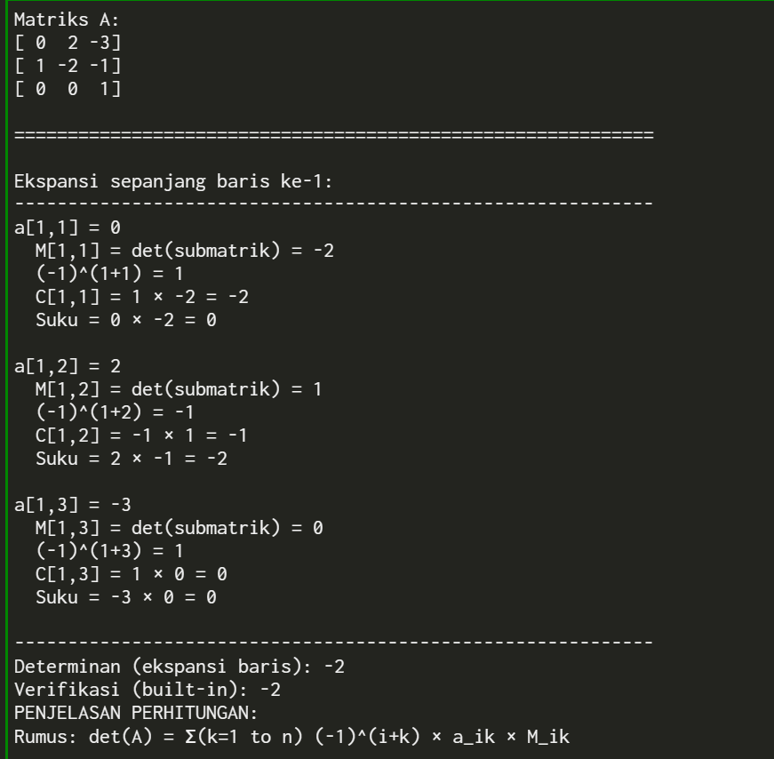

```python
from IPython.display import Image
Image("PT9c2.png")
```

```python
# MATRIKS 3: 4×4

# Definisi matriks
A = matrix([[1, -3, 1, 1],
            [-3, 1, 1, 1],
            [1, 1, -3, 1],
            [1, 1, 1, -3]])

print("Matriks A:")
print(A)

# Fungsi untuk menghitung minor
def minor(matrix, i, j):
    """
    M_ij = det(A_ij)
    dimana A_ij adalah submatrik setelah menghapus baris i dan kolom j
    """
    submatrix = matrix.delete_rows([i]).delete_columns([j])
    return submatrix.det()

# Fungsi untuk menghitung kofaktor
def cofactor(matrix, i, j):
    """
    C_ij = (-1)^(i+j) * M_ij
    """
    return (-1)^(i + j) * minor(matrix, i, j)

# Menghitung determinan dengan ekspansi baris
def determinant_expansion(matrix, row=0):
    """
    det(A) = Σ(k=0 to n-1) (-1)^(row+k) * a_(row,k) * M_(row,k)
    """
    n = matrix.ncols()
    det_value = 0

    print(f"\nEkspansi sepanjang baris ke-{row + 1}:")
    print("-" * 60)

    for k in range(n):
        a_ik = matrix[row, k]
        M_ik = minor(matrix, row, k)
        C_ik = cofactor(matrix, row, k)
        tanda = (-1)^(row + k)
        suku = a_ik * C_ik

        print(f"a[{row+1},{k+1}] = {a_ik}")
        print(f"  M[{row+1},{k+1}] = det(submatrik 3×3) = {M_ik}")
        print(f"  (-1)^({row+1}+{k+1}) = {tanda}")
        print(f"  C[{row+1},{k+1}] = {tanda} × {M_ik} = {C_ik}")
        print(f"  Suku = {a_ik} × {C_ik} = {suku}")
        print()

        det_value += suku

    print("-" * 60)
    return det_value

# Hitung determinan
det = determinant_expansion(A, row=0)

print(f"Determinan (ekspansi baris): {det}")
print(f"Verifikasi (built-in): {A.det()}")

# Penjelasan manual
print("PENJELASAN PERHITUNGAN:")
print("Rumus: det(A) = Σ(k=1 to n) (-1)^(i+k) × a_ik × M_ik")
print()
print("Untuk matriks 4×4 dengan ekspansi baris 1:")
print("det(A) = (-1)^(1+1) × a_11 × M_11")
print("       + (-1)^(1+2) × a_12 × M_12")
print("       + (-1)^(1+3) × a_13 × M_13")
print("       + (-1)^(1+4) × a_14 × M_14")
print()
print("dimana setiap M_1k adalah determinan matriks 3×3")
print("yang diperoleh dengan menghapus baris 1 dan kolom k")
print()
print("M_11 = det([[1,1,1],[1,-3,1],[1,1,-3]])")
print("M_12 = det([[-3,1,1],[1,-3,1],[1,1,-3]])")
print("M_13 = det([[-3,1,1],[1,1,1],[1,1,-3]])")
print("M_14 = det([[-3,1,1],[1,1,-3],[1,1,1]])")
print()
print("Setiap minor 3×3 dihitung lagi dengan ekspansi baris")
print("hingga menjadi determinan 2×2 atau 1×1")
```

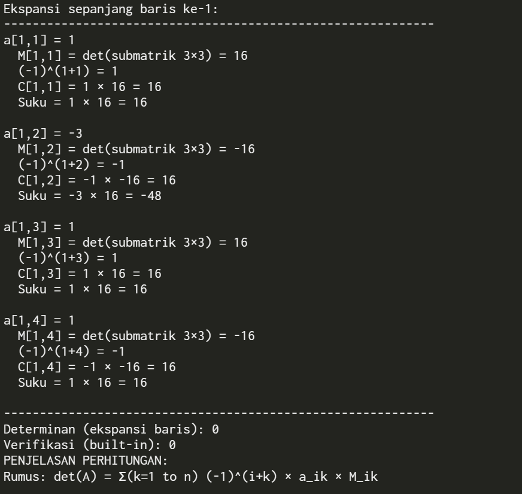

```python
from IPython.display import Image
Image("PT9c3.png")
```

**B. Gunakan rumus matriks adjoin untuk menghitung invers dari matriks berikut dengan rumus**

$$ (\text{adj } A)_{ij} = (-1)^{i+j} M_{ji} $$

dan

$$ A^{-1} = \frac{1}{\det A} \text{adj } A. $$

dimana:

- $M_{ji}$ adalah minor dari elemen baris $j$ dan kolom $i$
- $\text{adj } A$ adalah matriks adjoin (transpose dari matriks kofaktor)
- $\det A$ adalah determinan dari matriks $A$

### **Bagian B: Penjelasan Invers Matriks dengan Metode Adjoin**

**Rumus yang Digunakan:** $$ (\text{adj } A)_{ij} = (-1)^{i+j} \cdot M_{ji} $$ $$ A^{-1} = \frac{1}{\det A} \cdot \text{adj } A $$

**Langkah Matematis:**

1. **Cek Determinan:** Hitung $\det(A)$. Jika $\det(A) = 0$, matriks bersifat singular dan **tidak memiliki invers**.
2. **Hitung Matriks Kofaktor:** Hitung kofaktor $C_{ji} = (-1)^{j+i} \cdot M_{ji}$ untuk setiap posisi. Perhatikan indeksnya tertukar ($j,i$) karena langkah berikutnya melibatkan transpose.
3. **Bentuk Matriks Adjoin:** Adjoin adalah **transpose** dari matriks kofaktor. Secara praktis, elemen di posisi $(i,j)$ pada matriks adjoin diisi oleh kofaktor dari posisi $(j,i)$ pada matriks asli.
4. **Hitung Invers:** Kalikan seluruh matriks adjoin dengan skalar $\frac{1}{\det(A)}$ untuk mendapatkan $A^{-1}$.

**Implementasi dalam Kode SageMath:**

### Soal Invers Matriks dengan Metode Adjoin

**4.** Matriks 2×2: $$ A = \begin{bmatrix} -7 & -5 \\ 1 & 4 \end{bmatrix} $$

**5.** Matriks 3×3: $$ A = \begin{bmatrix} 0 & 2 & -3 \\ 1 & -2 & -1 \\ 0 & 0 & 1 \end{bmatrix} $$

**6.** Matriks 4×4: $$ A = \begin{bmatrix} 1 & -3 & 1 & 1 \\ -3 & 1 & 1 & 1 \\ 1 & 1 & -3 & 1 \\ 1 & 1 & 1 & -3 \end{bmatrix} $$

**Rumus yang digunakan:**

$$ (\text{adj } A)_{ij} = (-1)^{i+j} M_{ji} $$

$$ A^{-1} = \frac{1}{\det A} \text{adj } A $$

```python
# MATRIKS 4: 2×2 - Invers dengan Metode Adjoin

# Definisi matriks
A = matrix([[-7, -5],
            [1, 4]])

print("Matriks A:")
print(A)
print("\n" + "="*60)

# Fungsi untuk menghitung minor
def minor(matrix, i, j):
    """
    M_ij = det(A_ij)
    dimana A_ij adalah submatrik setelah menghapus baris i dan kolom j
    """
    # SageMath menggunakan indeks 0-based
    submatrix = matrix.delete_rows([i]).delete_columns([j])
    return submatrix.det()

# Fungsi untuk menghitung kofaktor
def cofactor(matrix, i, j):
    """
    C_ij = (-1)^(i+j) * M_ij
    """
    return (-1)^(i + j) * minor(matrix, i, j)

# Fungsi untuk menghitung matriks adjoin
def adjoint(matrix):
    """
    adj(A) = transpose dari matriks kofaktor
    (adj A)_ij = (-1)^(i+j) * M_ji
    """
    n = matrix.nrows()

    # PERBAIKAN: Gunakan zero_matrix(n, n) bukan matrix.zeros(n)
    cofactor_matrix = zero_matrix(n, n)

    print("Matriks Kofaktor:")
    print("-" * 60)

    for i in range(n):
        for j in range(n):
            # Hitung kofaktor C_ji (karena adjoin adalah transpose)
            # Posisi (i,j) pada adjoin berasal dari kofaktor posisi (j,i)
            C_ji = cofactor(matrix, j, i)
            cofactor_matrix[i, j] = C_ji

            print(f"C({j+1},{i+1}) = (-1)^({j+1}+{i+1}) × M({j+1},{i+1}) = {C_ji}")
        print()

    print("-" * 60)
    print("Matriks Kofaktor (sebelum transpose):")
    print(cofactor_matrix)
    print()

    # Adjoin adalah transpose dari matriks kofaktor
    adj = cofactor_matrix.transpose()
    print("Matriks Adjoin (transpose dari matriks kofaktor):")
    print(adj)

    return adj

# Fungsi untuk menghitung invers dengan metode adjoin
def inverse_by_adjoint(matrix):
    """
    A^{-1} = (1/det(A)) * adj(A)
    """
    # Hitung determinan
    det_A = matrix.det()
    print(f"\nDeterminan A: {det_A}")

    if det_A == 0:
        print("Matriks tidak memiliki invers (determinan = 0)")
        return None

    # Hitung matriks adjoin
    adj_A = adjoint(matrix)

    # Hitung invers
    print("PERHITUNGAN INVERS:")
    print(f"A^(-1) = (1/{det_A}) * adj(A)")
    print()

    inv_A = (1/det_A) * adj_A

    print("Hasil:")
    print(inv_A)

    return inv_A

# Hitung invers
print("PERHITUNGAN INVERS MATRIKS 2×2")
inv_A = inverse_by_adjoint(A)

# Verifikasi
print("VERIFIKASI:")
print("A * A^(-1) =")
print(A * inv_A)
print("\nA^(-1) * A =")
print(inv_A * A)

# Bandingkan dengan built-in
print("PERBANDINGAN:")
print(f"Invers (metode adjoin):\n{inv_A}")
print(f"\nInvers (built-in):\n{A.inverse()}")
print(f"\nHasil sama: {inv_A == A.inverse()}")
```

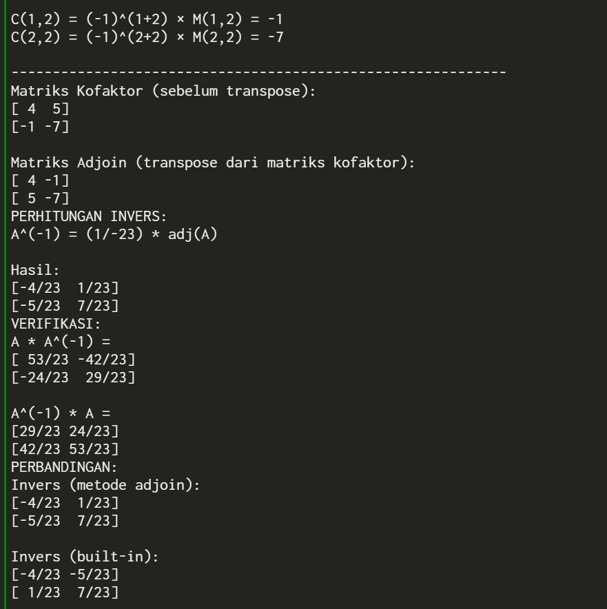

```python
from IPython.display import Image
Image("PT9c4.png")
```

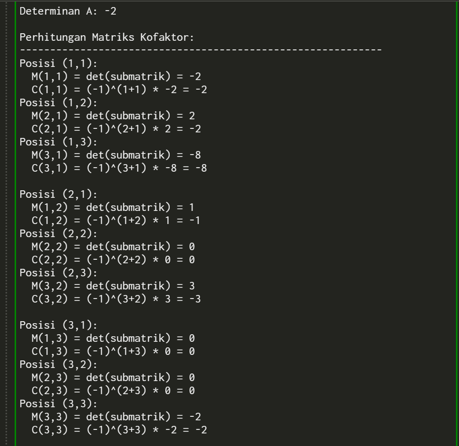

```python
from IPython.display import Image
Image("PT9c5.png")
```

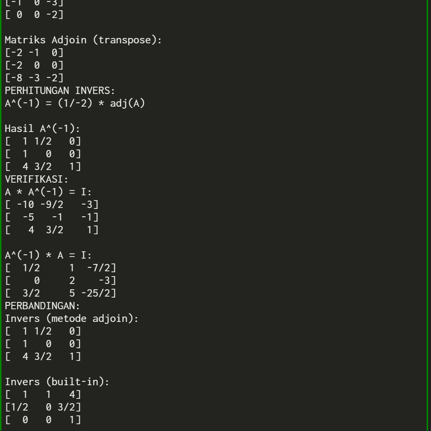

```python
from IPython.display import Image
Image("PT9c6.png")
```

```python
# MATRIKS 6: 4×4 - Invers dengan Metode Adjoin

# Definisi matriks
A = matrix([[1, -3, 1, 1],
            [-3, 1, 1, 1],
            [1, 1, -3, 1],
            [1, 1, 1, -3]])

print("Matriks A:")
print(A)
print("\n" + "="*60)

# Fungsi untuk menghitung minor
def minor(matrix, i, j):
    """
    M_ij = det(A_ij)
    """
    submatrix = matrix.delete_rows([i]).delete_columns([j])
    return submatrix.det()

# Fungsi untuk menghitung kofaktor
def cofactor(matrix, i, j):
    """
    C_ij = (-1)^(i+j) * M_ij
    """
    return (-1)^(i + j) * minor(matrix, i, j)

# Fungsi untuk menghitung matriks adjoin
def adjoint(matrix):
    """
    adj(A) = transpose dari matriks kofaktor
    (adj A)_ij = (-1)^(i+j) * M_ji
    """
    n = matrix.nrows()
    cofactor_matrix = zero_matrix(n, n)

    print("\nPerhitungan Matriks Kofaktor:")
    print("-" * 60)

    for i in range(n):
        for j in range(n):
            # Hitung kofaktor C_ji (karena adjoin adalah transpose)
            M_ji = minor(matrix, j, i)
            C_ji = (-1)^(j + i) * M_ji
            cofactor_matrix[i, j] = C_ji

            # Output format detail (konsisten dengan no 4 & 5)
            print(f"Elemen Adjoin posisi ({i+1},{j+1}):")
            print(f"  M({j+1},{i+1}) = det(submatrik) = {M_ji}")
            print(f"  Tanda = (-1)^({j+1}+{i+1}) = {(-1)^(j+i)}")
            print(f"  C({j+1},{i+1}) = {(-1)^(j+i)} * {M_ji} = {C_ji}")
            print()

    print("-" * 60)
    print("Matriks Kofaktor:")
    print(cofactor_matrix)
    print()

    # Adjoin = transpose matriks kofaktor
    adj = cofactor_matrix.transpose()
    print("Matriks Adjoin (transpose dari matriks kofaktor):")
    print(adj)

    return adj

# Fungsi untuk menghitung invers
def inverse_by_adjoint(matrix):
    """
    A^{-1} = (1/det(A)) * adj(A)
    """
    det_A = matrix.det()
    print(f"\nDeterminan A: {det_A}")

    if det_A == 0:
        print("Matriks tidak memiliki invers (determinan = 0)")
        return None

    adj_A = adjoint(matrix)

    print("PERHITUNGAN INVERS:")
    print(f"A^(-1) = (1/{det_A}) * adj(A)")
    print()

    inv_A = (1/det_A) * adj_A

    print("Hasil A^(-1):")
    print(inv_A)

    return inv_A

# Hitung invers
print("PERHITUNGAN INVERS MATRIKS 4×4")
inv_A = inverse_by_adjoint(A)

# Verifikasi
if inv_A is not None:
    print("VERIFIKASI:")
    print("A * A^(-1) =")
    print(A * inv_A)
    print("\nA^(-1) * A =")
    print(inv_A * A)

    # Bandingkan
    print("PERBANDINGAN:")
    print(f"Invers (metode adjoin):\n{inv_A}")
    print(f"\nInvers (built-in):\n{A.inverse()}")
    print(f"\nHasil sama: {inv_A == A.inverse()}")
```

[output not shown]

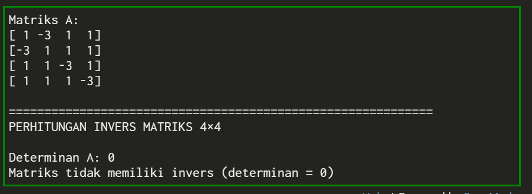

```python
from IPython.display import Image
Image("PT9c7.png")
```

## Pertemuan 11

```python
import numpy as np
import matplotlib.pyplot as plt
from matplotlib.animation import FuncAnimation
from IPython.display import HTML

# ==========================================
# TITIK AWAL ABCD
# ==========================================

x = np.array([2, 2, 3, 3, 2])
y = np.array([3, 4, 4, 3, 3])

# ==========================================
# CERMINAN AWAL EFGH
# ==========================================

x_cermin = np.array([2, 3, 3, 2, 2])
y_cermin = np.array([-3, -3, -4, -4, -3])

# ==========================================
# MEMBUAT GRAFIK
# ==========================================

fig, ax = plt.subplots(figsize=(7,7))

ax.set_xlim(-2, 6)
ax.set_ylim(-8, 8)

ax.set_xticks(np.arange(-2, 7, 1))
ax.set_yticks(np.arange(-8, 9, 1))

ax.grid(True)

ax.set_aspect('equal')

# Garis objek awal
line_asli, = ax.plot([], [],
                     marker='o',
                     linewidth=2,
                     label="ABCD")

# Garis hasil translasi
line_hasil, = ax.plot([], [],
                      marker='o',
                      linewidth=2,
                      label="IJKL")

# Garis cerminan awal
line_cermin, = ax.plot([], [],
                       '--',
                       marker='o',
                       linewidth=2,
                       label="EFGH")

# Garis cerminan hasil
line_cermin_hasil, = ax.plot([], [],
                             '--',
                             marker='o',
                             linewidth=2,
                             label="MNOP")

# ==========================================
# LABEL TITIK
# ==========================================

label_awal = ["A","B","C","D"]
label_hasil = ["I","J","K","L"]

label_cermin = ["E","F","H","G"]
label_cermin_hasil = ["M","N","P","O"]

texts_awal = [ax.text(0,0,"") for _ in range(4)]
texts_hasil = [ax.text(0,0,"") for _ in range(4)]

texts_cermin = [ax.text(0,0,"") for _ in range(4)]
texts_cermin_hasil = [ax.text(0,0,"") for _ in range(4)]

# Sumbu
ax.axhline(0,color='black')
ax.axvline(0,color='black')

ax.legend()

# ==========================================
# INIT
# ==========================================

def init():

    line_asli.set_data([], [])
    line_hasil.set_data([], [])

    line_cermin.set_data([], [])
    line_cermin_hasil.set_data([], [])

    return (line_asli,
            line_hasil,
            line_cermin,
            line_cermin_hasil)

# ==========================================
# ANIMASI
# ==========================================

def update(frame):

    # translasi atas-bawah
    ty = np.sin(frame * 0.2) * 2
    tx = 0

    # hasil translasi ABCD -> IJKL
    x_hasil = x + tx
    y_hasil = y + ty

    # hasil translasi cerminan EFGH -> MNOP
    x_cermin_hasil = x_cermin + tx
    y_cermin_hasil = y_cermin + ty

    # garis
    line_asli.set_data(x, y)

    line_hasil.set_data(x_hasil, y_hasil)

    line_cermin.set_data(x_cermin, y_cermin)

    line_cermin_hasil.set_data(
        x_cermin_hasil,
        y_cermin_hasil
    )

    # ======================================
    # LABEL TITIK
    # ======================================

    for i in range(4):

        # titik awal
        texts_awal[i].set_position((x[i], y[i]))
        texts_awal[i].set_text(label_awal[i])

        # titik hasil
        texts_hasil[i].set_position(
            (x_hasil[i], y_hasil[i])
        )
        texts_hasil[i].set_text(label_hasil[i])

        # cerminan awal
        texts_cermin[i].set_position(
            (x_cermin[i], y_cermin[i])
        )
        texts_cermin[i].set_text(label_cermin[i])

        # cerminan hasil
        texts_cermin_hasil[i].set_position(
            (x_cermin_hasil[i],
             y_cermin_hasil[i])
        )

        texts_cermin_hasil[i].set_text(
            label_cermin_hasil[i]
        )

    return (line_asli,
            line_hasil,
            line_cermin,
            line_cermin_hasil,
            *texts_awal,
            *texts_hasil,
            *texts_cermin,
            *texts_cermin_hasil)

# ==========================================
# MENJALANKAN ANIMASI
# ==========================================

ani = FuncAnimation(
    fig,
    update,
    frames=100,
    init_func=init,
    interval=100
)

plt.close(fig)

HTML(ani.to_jshtml())
```

[figure not shown]

## Pertemuan 12

```python
import numpy as np

# Matriks A
A = np.array([
    [2, 2, 0, 0],
    [2, -2, 0, 0],
    [0, 0, 3, 3],
    [0, 0, 3, -3]
], dtype=float)

# QR Decomposition
Q, R = np.linalg.qr(A)

# Ubah supaya diagonal R positif
for i in range(len(R)):
    if R[i, i] < 0:
        Q[:, i] *= -1
        R[i, :] *= -1

# Output
print("Matriks A:")
print(A)

print("\nMatriks Q:")
print(np.round(Q, 3))

print("\nMatriks R:")
print(np.round(R, 3))

print("\nq1:")
print(np.round(Q[:, 0], 3))

print("\nq2:")
print(np.round(Q[:, 1], 3))

print("\nq3:")
print(np.round(Q[:, 2], 3))

print("\nq4:")
print(np.round(Q[:, 3], 3))
```

```
Matriks A:
[[ 2.  2.  0.  0.]
 [ 2. -2.  0.  0.]
 [ 0.  0.  3.  3.]
 [ 0.  0.  3. -3.]]

Matriks Q:
[[ 0.707  0.707 -0.    -0.   ]
 [ 0.707 -0.707 -0.    -0.   ]
 [ 0.     0.     0.707  0.707]
 [ 0.     0.     0.707 -0.707]]

Matriks R:
[[ 2.828 -0.    -0.    -0.   ]
 [-0.     2.828 -0.    -0.   ]
 [-0.    -0.     4.243 -0.   ]
 [-0.    -0.    -0.     4.243]]

q1:
[0.707 0.707 0.    0.   ]

q2:
[ 0.707 -0.707  0.     0.   ]

q3:
[-0.    -0.     0.707  0.707]

q4:
[-0.    -0.     0.707 -0.707]
```

[figure not shown]

```python
from IPython.display import Image
Image("PT12c1.JPG")
```

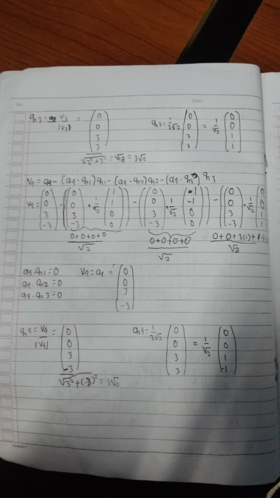

```python
from IPython.display import Image
Image("PT12c2.JPG")
```

[figure not shown]

```python
from IPython.display import Image
Image("PT12c3.JPG")
```

## Pertemuan 14

### Singular Value Decomposition (SVD)

Salah satu konsep terpenting dalam aljabar linear adalah **Singular Value Decomposition (SVD)**, yaitu teknik faktorisasi matriks yang memecah sebuah matriks menjadi tiga matriks yang berbeda.

$$ A = U \Sigma V^T $$

Kita dapat menerapkan dekomposisi ini pada sembarang matriks berukuran $m \times n$, sehingga diperoleh tiga matriks:

- **U**: Matriks ortogonal berukuran $m \times m$. Kolom-kolom matriks ini merupakan **vektor singular kiri (left singular vectors)** dari matriks $A$.
- **Σ (Sigma)**: Matriks diagonal berukuran $m \times n$. Nilai-nilai pada diagonalnya dilambangkan dengan $\sigma_i$ dan disebut **nilai singular (singular values)** dari matriks $A$.
- **Vᵀ**: Transpos dari matriks ortogonal berukuran $n \times n$. Kolom-kolom matriks $V$ (sebelum ditranspos) merupakan **vektor singular kanan (right singular vectors)** dari matriks $A$.

Kita dapat menghitung dekomposisi ini dengan menganalisis nilai eigen (*eigenvalues*) dan vektor eigen (*eigenvectors*) dari matriks:

$$ A^T A $$

dan

$$ A A^T $$

Nilai eigen dari kedua matriks tersebut sama dengan kuadrat dari nilai singular.

Setelah itu, nilai-nilai singular diurutkan dari yang terbesar ke yang terkecil dan ditempatkan pada diagonal matriks $\Sigma$. Dengan mempertahankan urutan yang sama, kolom-kolom matriks $U$ dibentuk dari vektor-vektor eigen matriks $AA^T$, sedangkan kolom-kolom matriks $V$ diperoleh dari vektor-vektor eigen matriks $A^TA$.

## Interpretasi Geometris

Secara geometris, matriks $A$ dapat dipandang sebagai suatu transformasi linear dari ruang:

$$ \mathbb{R}^n \rightarrow \mathbb{R}^m $$

SVD memungkinkan kita mendekomposisi matriks bahkan ketika dimensi ruang asal dan ruang tujuan berbeda.

Matriks $A$ dapat merepresentasikan transformasi yang memproyeksikan vektor dari dimensi yang lebih tinggi ke dimensi yang lebih rendah, atau sebaliknya ketika $m > n$.

Meskipun data dapat dipindahkan ke ruang berdimensi lebih tinggi, dimensi intrinsik data tersebut tetap sama. Analogi sederhananya adalah selembar kertas dua dimensi yang ditempatkan di dalam ruangan tiga dimensi. Kertas tersebut dapat diputar dan diregangkan, tetapi tidak akan pernah memenuhi seluruh ruang tiga dimensi. Data tersebut tetap memiliki sifat dua dimensi.

Konsep ini membantu kita memahami jumlah nilai singular dan berbagai aplikasi SVD.

## Transformasi pada SVD

Dengan menggunakan SVD, transformasi linear dapat dipandang sebagai tiga transformasi terpisah yang diterapkan dari kanan ke kiri:

1. **Rotasi oleh $V^T$**

   Karena $V^T$ adalah matriks berukuran $n \times n$, transformasi ini merepresentasikan rotasi pada ruang masukan (*input space*).
2. **Penskalaan oleh $\Sigma$**

   Matriks $\Sigma$ melakukan penskalaan menggunakan nilai singular $\sigma_i$. Jumlah nilai singular maksimum adalah:

   $$ \min(m,n) $$

   Selain melakukan penskalaan, matriks ini juga dapat menambahkan dimensi dengan nilai nol.
3. **Rotasi oleh $U$**

   Karena $U$ adalah matriks berukuran $m \times m$, transformasi ini merepresentasikan rotasi pada ruang keluaran (*output space*) $\mathbb{R}^m$.

## Ringkasan

Dekomposisi Singular Value Decomposition (SVD) memecah suatu matriks menjadi:

$$ A = U \Sigma V^T $$

dengan:

- $U$ : vektor singular kiri
- $\Sigma$ : nilai singular
- $V^T$ : vektor singular kanan

SVD banyak digunakan dalam:

- Kompresi data dan gambar
- Principal Component Analysis (PCA)
- Sistem rekomendasi
- Pemrosesan sinyal
- Machine Learning dan Data Science

# Singular Value Decomposition (SVD)

## Pendahuluan

Singular Value Decomposition (SVD) adalah teknik faktorisasi matriks untuk menguraikan sebuah matriks menjadi tiga matriks lainnya, sehingga mengungkapkan aspek penting dari struktur matriks aslinya.

SVD digunakan dalam berbagai aplikasi, seperti:

- Pemrosesan sinyal
- Kompresi gambar
- Machine Learning
- Data Mining
- Reduksi dimensi (PCA)
- Sistem rekomendasi

Materi ini mengasumsikan pemahaman dasar mengenai:

- Norma vektor dan matriks
- Rank matriks
- Nilai eigen dan vektor eigen
- Vektor ortonormal
- Proyeksi linear

# Definisi Matematis

Dekomposisi nilai singular dari matriks riil $A$ berukuran $m \times n$ adalah:

$$ A = U \Sigma V^T $$

dengan:

### Matriks U

$U$ adalah matriks ortogonal berukuran $m \times m$.

Kolom-kolomnya disebut:

**Vektor Singular Kiri (Left Singular Vectors)**

Sifat:

$$ U^T U = I $$

### Matriks Σ (Sigma)

$\Sigma$ adalah matriks diagonal berukuran $m \times n$.

Elemen diagonalnya disebut nilai singular:

$$ \sigma_1 \ge \sigma_2 \ge \cdots \ge \sigma_r \ge 0 $$

Jumlah nilai singular tidak nol sama dengan rank matriks.

### Matriks V

$V$ adalah matriks ortogonal berukuran $n \times n$.

Kolom-kolomnya disebut:

**Vektor Singular Kanan (Right Singular Vectors)**

Sifat:

$$ V^T V = I $$

# Algoritma SVD

## Langkah 1: Menghitung Vektor Singular Kiri

Hitung:

$$ AA^T $$

Kemudian cari nilai eigennya.

Jika terdapat $k$ nilai eigen tidak nol, maka:

$$ \text{rank}(A)=k $$

## Langkah 2: Membentuk Matriks U

Cari vektor eigen dari:

$$ AA^T $$

Normalisasi:

$$ u_i = \frac{u_i}{||u_i||} $$

Susun sebagai kolom matriks:

$$ U=[u_1\ u_2\ \cdots\ u_m] $$

## Langkah 3: Menghitung Nilai Singular

Hitung:

$$ A^TA $$

Cari nilai eigennya:

$$ \lambda_1,\lambda_2,\dots,\lambda_n $$

Nilai singular diperoleh dari:

$$ \sigma_i=\sqrt{\lambda_i} $$

## Langkah 4: Membentuk Matriks V

Cari vektor eigen dari:

$$ A^TA $$

Normalisasi seluruh vektor eigen.

Susun menjadi:

$$ V=[v_1\ v_2\ \cdots\ v_n] $$

Kemudian hitung:

$$ V^T $$

## Langkah 5: Membentuk Matriks Sigma

Bentuk matriks diagonal:

$$ \Sigma= \begin{bmatrix} \sigma_1 & 0 & \cdots\\ 0 & \sigma_2 & \cdots\\ \vdots & \vdots & \ddots \end{bmatrix} $$

Nilai singular diurutkan dari terbesar ke terkecil.

## Langkah 6: Hasil Dekomposisi

Matriks dapat direkonstruksi dengan:

$$ A=U\Sigma V^T $$

# Ilustrasi Dimensi

$$ A_{m\times n} = U_{m\times m} \cdot \Sigma_{m\times n} \cdot V^T_{n\times n} $$

# Catatan Penting

1. Nilai eigen dari $AA^T$ dan $A^TA$ sama.
2. Nilai singular selalu real dan non-negatif.
3. U dan V merupakan matriks ortogonal.

# Contoh Perhitungan SVD

Diberikan matriks:

$$ A= \begin{bmatrix} 3 & 1 & 1\\ -1 & 3 & 1 \end{bmatrix} $$

Ukuran matriks:

$$ 2\times3 $$

# Langkah 1: Menghitung AAᵀ

$$ AA^T= \begin{bmatrix} 3 & 1 & 1\\ -1 & 3 & 1 \end{bmatrix} \begin{bmatrix} 3 & -1\\ 1 & 3\\ 1 & 1 \end{bmatrix} $$

Hasil:

$$ AA^T= \begin{bmatrix} 11 & 1\\ 1 & 11 \end{bmatrix} $$

# Langkah 2: Nilai Eigen AAᵀ

Persamaan karakteristik:

$$ \det(AA^T-\lambda I)=0 $$

$$ \det \begin{bmatrix} 11-\lambda & 1\\ 1 & 11-\lambda \end{bmatrix} =0 $$

$$ (11-\lambda)^2-1=0 $$

$$ \lambda^2-22\lambda+120=0 $$

$$ (\lambda-12)(\lambda-10)=0 $$

Sehingga:

$$ \lambda_1=12 $$

$$ \lambda_2=10 $$

Rank matriks:

$$ \text{rank}(A)=2 $$

# Langkah 3: Membentuk Matriks U

## Untuk λ₁ = 12

Vektor eigen:

$$ u_1= \begin{bmatrix} 1\\ 1 \end{bmatrix} $$

Normalisasi:

$$ u_1= \begin{bmatrix} \frac1{\sqrt2}\\ \frac1{\sqrt2} \end{bmatrix} $$

## Untuk λ₂ = 10

Vektor eigen:

$$ u_2= \begin{bmatrix} 1\\ -1 \end{bmatrix} $$

Normalisasi:

$$ u_2= \begin{bmatrix} \frac1{\sqrt2}\\ -\frac1{\sqrt2} \end{bmatrix} $$

## Matriks U

$$ U= \begin{bmatrix} \frac1{\sqrt2} & \frac1{\sqrt2}\\ \frac1{\sqrt2} & -\frac1{\sqrt2} \end{bmatrix} $$

# Nilai Singular

$$ \sigma_1=\sqrt{12}=2\sqrt3 $$

$$ \sigma_2=\sqrt{10} $$

# Langkah 4: Menghitung AᵀA

$$ A^TA= \begin{bmatrix} 3 & -1\\ 1 & 3\\ 1 & 1 \end{bmatrix} \begin{bmatrix} 3 & 1 & 1\\ -1 & 3 & 1 \end{bmatrix} $$

Hasil:

$$ A^TA= \begin{bmatrix} 10 & 0 & 2\\ 0 & 10 & 4\\ 2 & 4 & 2 \end{bmatrix} $$

# Nilai Eigen AᵀA

$$ \lambda_1=12 $$

$$ \lambda_2=10 $$

$$ \lambda_3=0 $$

Karena:

$$ \text{rank}(A)=2 $$

maka hanya ada dua nilai singular yang tidak nol.

# Matriks Sigma

Karena ukuran matriks A adalah:

$$ 2\times3 $$

maka:

$$ \Sigma= \begin{bmatrix} \sqrt{12} & 0 & 0\\ 0 & \sqrt{10} & 0 \end{bmatrix} $$

# Hasil Akhir SVD

$$ A = U\Sigma V^T $$

dengan:

$$ U= \begin{bmatrix} \frac1{\sqrt2} & \frac1{\sqrt2}\\ \frac1{\sqrt2} & -\frac1{\sqrt2} \end{bmatrix} $$

$$ \Sigma= \begin{bmatrix} \sqrt{12} & 0 & 0\\ 0 & \sqrt{10} & 0 \end{bmatrix} $$

dan

$$ V^T= \begin{bmatrix} \frac1{\sqrt6} & \frac2{\sqrt6} & \frac1{\sqrt6}\\ \frac2{\sqrt5} & \frac{-1}{\sqrt5} & 0\\ \frac1{\sqrt{30}} & \frac2{\sqrt{30}} & \frac{-5}{\sqrt{30}} \end{bmatrix} $$

# Implementasi SageMath

```
A = matrix(RDF, [
    [3, 1, 1],
    [-1, 3, 1]
])

U, Sigma, Vt = A.SVD()

show(html("<h3>Matriks U</h3>"))
show(U)

show(html("<h3>Matriks Σ</h3>"))
show(Sigma)

show(html("<h3>Matriks Vᵀ</h3>"))
show(Vt)

show(html("<h3>Nilai Singular</h3>"))
show(A.singular_values())
```

# Verifikasi

```
A = matrix([
    [3,1,1],
    [-1,3,1]
])

AAT = A * A.transpose()

u1 = vector([1,1]).normalized()
u2 = vector([1,-1]).normalized()

U = matrix.column([u1,u2])

Sigma = matrix(SR,[
    [sqrt(12),0,0],
    [0,sqrt(10),0]
])

v1 = (A.transpose()*u1)/sqrt(12)
v2 = (A.transpose()*u2)/sqrt(10)

Vtemp = matrix.column([v1,v2])

v3 = Vtemp.transpose().right_kernel().basis()[0].normalized()

V = matrix.column([v1,v2,v3])

show(html("<h3>U</h3>"))
show(U)

show(html("<h3>Σ</h3>"))
show(Sigma)

show(html("<h3>V</h3>"))
show(V)

show(html("<h3>Vᵀ</h3>"))
show(V.transpose())

show(html("<h3>UΣVᵀ</h3>"))
show(U * Sigma * V.transpose())
```

# Kesimpulan

Singular Value Decomposition (SVD) memfaktorkan matriks:

$$ A=U\Sigma V^T $$

menjadi tiga komponen utama:

- Matriks U (vektor singular kiri)
- Matriks Σ (nilai singular)
- Matriks V (vektor singular kanan)

SVD banyak digunakan dalam:

- Kompresi data
- Kompresi gambar
- PCA
- Machine Learning
- Data Science
- Sistem rekomendasi
- Pemrosesan sinyal

### **Contoh Soal**

#### SageMathCell

### Singular Value Decomposition (SVD)

#### Diketahui

$$ A= \begin{bmatrix} 4 & 2 & 2\\ -2 & 4 & 2 \end{bmatrix} $$

## 1. Menghitung $AA^T$

$$ AA^T= \begin{bmatrix} 4 & 2 & 2\\ -2 & 4 & 2 \end{bmatrix} \begin{bmatrix} 4 & -2\\ 2 & 4\\ 2 & 2 \end{bmatrix} $$

$$ AA^T= \begin{bmatrix} 24 & 4\\ 4 & 24 \end{bmatrix} $$

## 2. Menentukan Nilai Eigen

Persamaan karakteristik:

$$ \det(AA^T-\lambda I)=0 $$

$$ \det \begin{bmatrix} 24-\lambda & 4\\ 4 & 24-\lambda \end{bmatrix} =0 $$

$$ (24-\lambda)^2-16=0 $$

$$ \lambda^2-48\lambda+560=0 $$

$$ (\lambda-28)(\lambda-20)=0 $$

Sehingga diperoleh:

$$ \lambda_1 = 28 $$

$$ \lambda_2 = 20 $$

## 3. Menentukan Vektor Eigen dan Matriks U

### Untuk $\lambda_1 = 28$

$$ \begin{bmatrix} -4 & 4\\ 4 & -4 \end{bmatrix} \begin{bmatrix} x_1\\ x_2 \end{bmatrix} = \begin{bmatrix} 0\\ 0 \end{bmatrix} $$

$$ x_1=x_2 $$

Vektor eigen:

$$ u_1= \begin{bmatrix} 1\\ 1 \end{bmatrix} $$

Normalisasi:

$$ u_1= \begin{bmatrix} \frac1{\sqrt2}\\ \frac1{\sqrt2} \end{bmatrix} $$

### Untuk $\lambda_2 = 20$

$$ \begin{bmatrix} 4 & 4\\ 4 & 4 \end{bmatrix} \begin{bmatrix} x_1\\ x_2 \end{bmatrix} = \begin{bmatrix} 0\\ 0 \end{bmatrix} $$

$$ x_1=-x_2 $$

Vektor eigen:

$$ u_2= \begin{bmatrix} 1\\ -1 \end{bmatrix} $$

Normalisasi:

$$ u_2= \begin{bmatrix} \frac1{\sqrt2}\\ -\frac1{\sqrt2} \end{bmatrix} $$

### Matriks U

$$ U= \begin{bmatrix} \frac1{\sqrt2} & \frac1{\sqrt2}\\ \frac1{\sqrt2} & -\frac1{\sqrt2} \end{bmatrix} $$

## 4. Menentukan Nilai Singular

$$ \sigma_1=\sqrt{\lambda_1} =\sqrt{28} =2\sqrt7 $$

$$ \sigma_2=\sqrt{\lambda_2} =\sqrt{20} =2\sqrt5 $$

## 5. Membentuk Matriks $\Sigma$

$$ \Sigma= \begin{bmatrix} 2\sqrt7 & 0 & 0\\ 0 & 2\sqrt5 & 0 \end{bmatrix} $$

## 6. Menentukan Vektor Singular Kanan

Menggunakan:

$$ v_i=\frac{A^Tu_i}{\sigma_i} $$

### Vektor $v_1$

$$ v_1= \frac{A^Tu_1}{2\sqrt7} $$

### Vektor $v_2$

$$ v_2= \frac{A^Tu_2}{2\sqrt5} $$

### Vektor $v_3$

Diperoleh dari kernel matriks:

$$ V_{temp}^T $$

## 9. Hasil Akhir SVD

$$ A = U\Sigma V^T $$

$$ \begin{bmatrix} 4 & 2 & 2\\ -2 & 4 & 2 \end{bmatrix} = U \Sigma V^T $$

Verifikasi menggunakan SageMath:

```
hasil = U * Sigma * V.transpose()
show(hasil.simplify_full())
```

Hasil rekonstruksi:

$$ \begin{bmatrix} 4 & 2 & 2\\ -2 & 4 & 2 \end{bmatrix} $$

Sehingga terbukti:

$$ A = U\Sigma V^T $$

# **Tugas Akhir Pertemuan 16**

## A. Soal Determinan Matriks 3×3

[output not shown]

### **Soal 1:**

Determinan matriks 3×3 dapat dihitung menggunakan **metode Sarrus** atau **ekspansi kofaktor**.

Untuk matriks $A = \begin{bmatrix} 2 & 1 & 3 \\ 0 & 4 & 5 \\ 1 & 2 & 1 \end{bmatrix}$

**Rumus:** $$\det(A) = a11 - a12 + a13$$

**Metode Ekspansi Kofaktor (baris pertama):** $$\det(A) = a\begin{vmatrix}e & f\\ h & i\end{vmatrix} - b\begin{vmatrix}d & f\\ g & i\end{vmatrix} + c\begin{vmatrix}d & e\\ g & h\end{vmatrix}$$

### **Jawaban Soal A 1:**

### SageMathCell

### Penjelasan Soal A1:

**Langkah :** Hitung minor untuk setiap elemen:

- Minor a₁₁ = det([[4,5],[2,1]]) = 4(1) - 5(2) = -6
- Minor a₁₂ = det([[0,5],[1,1]]) = 0(1) - 5(1) = -5
- Minor a₁₃ = det([[0,4],[1,2]]) = 0(2) - 4(1) = -4

**Hasil :** det(A) = 2(-6) - 1(-5) + 3(-4) = -12 + 5 - 12 = **-19**

### **Soal 2:**

Determinan matriks 3×3 dapat dihitung menggunakan **metode Sarrus** atau **ekspansi kofaktor**.

Untuk matriks $A = \begin{bmatrix} 3 & 2 & 1 \\ 1 & 0 & 4 \\ 2 & 5 & 1 \end{bmatrix}$

**Rumus:** $$\det(A) = a11 - a12 + a13$$

**Metode Ekspansi Kofaktor (baris pertama):** $$\det(A) = a\begin{vmatrix}e & f\\ h & i\end{vmatrix} - b\begin{vmatrix}d & f\\ g & i\end{vmatrix} + c\begin{vmatrix}d & e\\ g & h\end{vmatrix}$$

### **Jawaban Soal A 2:**

### SageMathCell

### Penjelasan Soal 2:

**Langkah :** Hitung minor:

- Minor b₁₁ = det([[0,4],[5,1]]) = 0(1) - 4(5) = -20
- Minor b₁₂ = det([[1,4],[2,1]]) = 1(1) - 4(2) = -7
- Minor b₁₃ = det([[1,0],[2,5]]) = 1(5) - 0(2) = 5

**Hasil:** det(B) = 3(-20) - 2(-7) + 1(5) = -60 + 14 + 5 = **-41**

## A. Soal Determinan Matriks 3×3

### **Soal 3:**

Determinan matriks 3×3 dapat dihitung menggunakan **metode Sarrus** atau **ekspansi kofaktor**.

Untuk matriks $A = \begin{bmatrix} 1 & 2 & 3 \\ 2 & 4 & 6 \\ 1 & 1 & 1 \end{bmatrix}$

**Rumus:** $$\det(A) = a11 - a12 + a13$$

**Metode Ekspansi Kofaktor (baris pertama):** $$\det(A) = a\begin{vmatrix}e & f\\ h & i\end{vmatrix} - b\begin{vmatrix}d & f\\ g & i\end{vmatrix} + c\begin{vmatrix}d & e\\ g & h\end{vmatrix}$$

### **Jawaban Soal A 3:**

### SageMathCell

### Penjelasan Soal 3:

**Hasil:** det(C) = **0**

**Kesimpulan:** Matriks C adalah **MATRIKS SINGULAR**

**Alasan:**

1. Determinan = 0, sehingga matriks tidak memiliki invers
2. **Analisis struktur matriks:**
   - Baris 1: [1, 2, 3]
   - Baris 2: [2, 4, 6] = 2 × [1, 2, 3]

   Baris 2 adalah kelipatan dari baris 1, artinya baris-baris tersebut **bergantung linear**.

**Sifat penting:** Jika ada baris/kolom yang bergantung linear (salah satu merupakan kelipatan dari yang lain), maka determinan matriks = 0 (singular).

## B. Soal Dekomposisi Matriks (LU Decomposition)

### Soal 4

Lakukan dekomposisi LU terhadap matriks:

$$ A = \begin{bmatrix} 2 & 4 & 2 \\ 1 & 5 & 2 \\ 1 & 2 & 4 \end{bmatrix} $$

dengan bentuk:

$$A = LU$$

di mana $L$ adalah matriks segitiga bawah dan $U$ adalah matriks segitiga atas.

### **Jawaban Soal B 4:**

### SageMathCell

### Soal 4

**Diketahui matriks:** $$ A = \begin{bmatrix} 2 & 4 & 2 \\ 1 & 5 & 2 \\ 1 & 2 & 4 \end{bmatrix} $$

### Langkah Penyelesaian (Eliminasi Gauss)

**Langkah 1: Eliminasi kolom ke-1** Gunakan $a_{11} = 2$ sebagai pivot.

- Pengali untuk baris 2: $m_{21} = \frac{1}{2} = 0.5$
  - $R_2 \leftarrow R_2 - 0.5 R_1 \implies [1, 5, 2] - [1, 2, 1] = [0, 3, 1]$
- Pengali untuk baris 3: $m_{31} = \frac{1}{2} = 0.5$
  - $R_3 \leftarrow R_3 - 0.5 R_1 \implies [1, 2, 4] - [1, 2, 1] = [0, 0, 3]$

**Langkah 2: Eliminasi kolom ke-2** Gunakan $a_{22} = 3$ sebagai pivot.

- Pengali untuk baris 3: $m_{32} = \frac{0}{3} = 0$
  - $R_3 \leftarrow R_3 - 0 R_2 \implies [0, 0, 3] - [0, 0, 0] = [0, 0, 3]$

### Hasil Akhir

Matriks $L$ diisi dengan nilai 1 pada diagonal utama dan pengali $m_{ij}$ pada posisi segitiga bawah: $$ L = \begin{bmatrix} 1 & 0 & 0 \\ 0.5 & 1 & 0 \\ 0.5 & 0 & 1 \end{bmatrix} $$

Matriks $U$ adalah hasil akhir dari eliminasi Gauss: $$ U = \begin{bmatrix} 2 & 4 & 2 \\ 0 & 3 & 1 \\ 0 & 0 & 3 \end{bmatrix} $$

### Soal 5

Tentukan matriks $L$ dan $U$ dari:

$$ B = \begin{bmatrix} 1 & 2 & 1 \\ 2 & 5 & 3 \\ 4 & 10 & 8 \end{bmatrix} $$

menggunakan metode eliminasi Gauss.

### **Jawaban Soal B 5:**

### SageMathCell

### Soal 5

**Diketahui matriks:** $$ B = \begin{bmatrix} 1 & 2 & 1 \\ 2 & 5 & 3 \\ 4 & 10 & 8 \end{bmatrix} $$

### Langkah Penyelesaian (Eliminasi Gauss)

**Langkah 1: Eliminasi kolom ke-1** Gunakan $b_{11} = 1$ sebagai pivot.

- Pengali untuk baris 2: $m_{21} = \frac{2}{1} = 2$
  - $R_2 \leftarrow R_2 - 2 R_1 \implies [2, 5, 3] - [2, 4, 2] = [0, 1, 1]$
- Pengali untuk baris 3: $m_{31} = \frac{4}{1} = 4$
  - $R_3 \leftarrow R_3 - 4 R_1 \implies [4, 10, 8] - [4, 8, 4] = [0, 2, 4]$

**Langkah 2: Eliminasi kolom ke-2** Gunakan $b_{22} = 1$ sebagai pivot.

- Pengali untuk baris 3: $m_{32} = \frac{2}{1} = 2$
  - $R_3 \leftarrow R_3 - 2 R_2 \implies [0, 2, 4] - [0, 2, 2] = [0, 0, 2]$

### Hasil Akhir

$$ L = \begin{bmatrix} 1 & 0 & 0 \\ 2 & 1 & 0 \\ 4 & 2 & 1 \end{bmatrix} \quad \text{dan} \quad U = \begin{bmatrix} 1 & 2 & 1 \\ 0 & 1 & 1 \\ 0 & 0 & 2 \end{bmatrix} $$

### Soal 6

Dekomposisikan matriks berikut menjadi $LU$:

$$ C = \begin{bmatrix} 4 & 2 & 0 \\ 2 & 5 & 1 \\ 0 & 1 & 3 \end{bmatrix} $$

### **Jawaban Soal B 6:**

### SageMathCell

### Soal 6

**Diketahui matriks:** $$ C = \begin{bmatrix} 4 & 2 & 0 \\ 2 & 5 & 1 \\ 0 & 1 & 3 \end{bmatrix} $$

### Langkah Penyelesaian (Eliminasi Gauss)

**Langkah 1: Eliminasi kolom ke-1** Gunakan $c_{11} = 4$ sebagai pivot.

- Pengali untuk baris 2: $m_{21} = \frac{2}{4} = 0.5$
  - $R_2 \leftarrow R_2 - 0.5 R_1 \implies [2, 5, 1] - [2, 1, 0] = [0, 4, 1]$
- Pengali untuk baris 3: $m_{31} = \frac{0}{4} = 0$
  - $R_3 \leftarrow R_3 - 0 R_1 \implies [0, 1, 3] - [0, 0, 0] = [0, 1, 3]$ *(Tidak berubah)*

**Langkah 2: Eliminasi kolom ke-2** Gunakan $c_{22} = 4$ sebagai pivot.

- Pengali untuk baris 3: $m_{32} = \frac{1}{4} = 0.25$
  - $R_3 \leftarrow R_3 - 0.25 R_2 \implies [0, 1, 3] - [0, 1, 0.25] = [0, 0, 2.75]$

### Hasil Akhir

$$ L = \begin{bmatrix} 1 & 0 & 0 \\ 0.5 & 1 & 0 \\ 0 & 0.25 & 1 \end{bmatrix} \quad \text{dan} \quad U = \begin{bmatrix} 4 & 2 & 0 \\ 0 & 4 & 1 \\ 0 & 0 & 2.75 \end{bmatrix} $$ *(Catatan: $2.75$ dapat juga ditulis sebagai pecahan $\frac{11}{4}$)*

## C. Soal Invers Matriks 3x3:

### Soal 7 - Invers Matriks 3×3

**Diketahui matriks:** $$ A = \begin{bmatrix} 1 & 2 & 1 \\ 0 & 1 & 1 \\ 2 & 3 & 4 \end{bmatrix} $$

**Tentukan invers dari matriks A** menggunakan metode adjoin atau eliminasi Gauss-Jordan.

### **Jawaban Soal C 7:**

### SageMathCell

### Pembahasan Soal 7

#### Metode yang Digunakan: Eliminasi Gauss-Jordan

**Langkah 1:** Bentuk matriks augmented $[A|I]$ $$ \left[\begin{array}{ccc|ccc} 1 & 2 & 1 & 1 & 0 & 0 \\ 0 & 1 & 1 & 0 & 1 & 0 \\ 2 & 3 & 4 & 0 & 0 & 1 \end{array}\right] $$

**Langkah 2:** Eliminasi elemen di bawah pivot kolom 1

- $R_3 \leftarrow R_3 - 2R_1$ $$ \left[\begin{array}{ccc|ccc} 1 & 2 & 1 & 1 & 0 & 0 \\ 0 & 1 & 1 & 0 & 1 & 0 \\ 0 & -1 & 2 & -2 & 0 & 1 \end{array}\right] $$

**Langkah 3:** Eliminasi elemen di bawah pivot kolom 2

- $R_3 \leftarrow R_3 + R_2$ $$ \left[\begin{array}{ccc|ccc} 1 & 2 & 1 & 1 & 0 & 0 \\ 0 & 1 & 1 & 0 & 1 & 0 \\ 0 & 0 & 3 & -2 & 1 & 1 \end{array}\right] $$

**Langkah 4:** Normalisasi pivot kolom 3

- $R_3 \leftarrow \frac{1}{3}R_3$ $$ \left[\begin{array}{ccc|ccc} 1 & 2 & 1 & 1 & 0 & 0 \\ 0 & 1 & 1 & 0 & 1 & 0 \\ 0 & 0 & 1 & -\frac{2}{3} & \frac{1}{3} & \frac{1}{3} \end{array}\right] $$

**Langkah 5:** Eliminasi elemen di atas pivot (back substitution)

- $R_2 \leftarrow R_2 - R_3$
- $R_1 \leftarrow R_1 - R_3$ $$ \left[\begin{array}{ccc|ccc} 1 & 2 & 0 & \frac{5}{3} & -\frac{1}{3} & -\frac{1}{3} \\ 0 & 1 & 0 & \frac{2}{3} & \frac{2}{3} & -\frac{1}{3} \\ 0 & 0 & 1 & -\frac{2}{3} & \frac{1}{3} & \frac{1}{3} \end{array}\right] $$

**Langkah 6:** Eliminasi elemen di atas pivot kolom 2

- $R_1 \leftarrow R_1 - 2R_2$ $$ \left[\begin{array}{ccc|ccc} 1 & 0 & 0 & \frac{1}{3} & -\frac{5}{3} & \frac{1}{3} \\ 0 & 1 & 0 & \frac{2}{3} & \frac{2}{3} & -\frac{1}{3} \\ 0 & 0 & 1 & -\frac{2}{3} & \frac{1}{3} & \frac{1}{3} \end{array}\right] $$

#### Hasil Akhir:

$$ A^{-1} = \begin{bmatrix} \frac{1}{3} & -\frac{5}{3} & \frac{1}{3} \\ \frac{2}{3} & \frac{2}{3} & -\frac{1}{3} \\ -\frac{2}{3} & \frac{1}{3} & \frac{1}{3} \end{bmatrix} = \frac{1}{3}\begin{bmatrix} 1 & -5 & 1 \\ 2 & 2 & -1 \\ -2 & 1 & 1 \end{bmatrix} $$

**Determinan:** $\det(A) = 3$

### Soal 8 - Invers Matriks 3×3

**Carilah invers matriks:** $$ B = \begin{bmatrix} 2 & 1 & 0 \\ 1 & 2 & 1 \\ 0 & 1 & 2 \end{bmatrix} $$

### **Jawaban Soal C 8:**

### SageMathCell

### Pembahasan Soal 8

#### Metode yang Digunakan: Eliminasi Gauss-Jordan

**Langkah 1:** Bentuk matriks augmented $[B|I]$ $$ \left[\begin{array}{ccc|ccc} 2 & 1 & 0 & 1 & 0 & 0 \\ 1 & 2 & 1 & 0 & 1 & 0 \\ 0 & 1 & 2 & 0 & 0 & 1 \end{array}\right] $$

**Langkah 2:** Normalisasi pivot kolom 1

- $R_1 \leftarrow \frac{1}{2}R_1$ $$ \left[\begin{array}{ccc|ccc} 1 & \frac{1}{2} & 0 & \frac{1}{2} & 0 & 0 \\ 1 & 2 & 1 & 0 & 1 & 0 \\ 0 & 1 & 2 & 0 & 0 & 1 \end{array}\right] $$

**Langkah 3:** Eliminasi elemen di bawah pivot kolom 1

- $R_2 \leftarrow R_2 - R_1$ $$ \left[\begin{array}{ccc|ccc} 1 & \frac{1}{2} & 0 & \frac{1}{2} & 0 & 0 \\ 0 & \frac{3}{2} & 1 & -\frac{1}{2} & 1 & 0 \\ 0 & 1 & 2 & 0 & 0 & 1 \end{array}\right] $$

**Langkah 4:** Normalisasi pivot kolom 2

- $R_2 \leftarrow \frac{2}{3}R_2$ $$ \left[\begin{array}{ccc|ccc} 1 & \frac{1}{2} & 0 & \frac{1}{2} & 0 & 0 \\ 0 & 1 & \frac{2}{3} & -\frac{1}{3} & \frac{2}{3} & 0 \\ 0 & 1 & 2 & 0 & 0 & 1 \end{array}\right] $$

**Langkah 5:** Eliminasi elemen di bawah dan atas pivot kolom 2

- $R_3 \leftarrow R_3 - R_2$
- $R_1 \leftarrow R_1 - \frac{1}{2}R_2$ $$ \left[\begin{array}{ccc|ccc} 1 & 0 & -\frac{1}{3} & \frac{2}{3} & -\frac{1}{3} & 0 \\ 0 & 1 & \frac{2}{3} & -\frac{1}{3} & \frac{2}{3} & 0 \\ 0 & 0 & \frac{4}{3} & \frac{1}{3} & -\frac{2}{3} & 1 \end{array}\right] $$

**Langkah 6:** Normalisasi pivot kolom 3

- $R_3 \leftarrow \frac{3}{4}R_3$ $$ \left[\begin{array}{ccc|ccc} 1 & 0 & -\frac{1}{3} & \frac{2}{3} & -\frac{1}{3} & 0 \\ 0 & 1 & \frac{2}{3} & -\frac{1}{3} & \frac{2}{3} & 0 \\ 0 & 0 & 1 & \frac{1}{4} & -\frac{1}{2} & \frac{3}{4} \end{array}\right] $$

**Langkah 7:** Eliminasi elemen di atas pivot kolom 3

- $R_2 \leftarrow R_2 - \frac{2}{3}R_3$
- $R_1 \leftarrow R_1 + \frac{1}{3}R_3$

#### Hasil Akhir:

$$ B^{-1} = \begin{bmatrix} \frac{3}{4} & -\frac{1}{2} & \frac{1}{4} \\ -\frac{1}{2} & 1 & -\frac{1}{2} \\ \frac{1}{4} & -\frac{1}{2} & \frac{3}{4} \end{bmatrix} = \frac{1}{4}\begin{bmatrix} 3 & -2 & 1 \\ -2 & 4 & -2 \\ 1 & -2 & 3 \end{bmatrix} $$

**Determinan:** $\det(B) = 4$

### Soal 9 - Invers Matriks 3×3

**Diketahui:** $$ C = \begin{bmatrix} 3 & 0 & 2 \\ 2 & 0 & -2 \\ 0 & 1 & 1 \end{bmatrix} $$

**Tentukan $C^{-1}$**

### **Jawaban Soal C 9:**

### SageMathCell

### Pembahasan Soal 9

#### Metode yang Digunakan: Eliminasi Gauss-Jordan

**Langkah 1:** Bentuk matriks augmented $[C|I]$ $$ \left[\begin{array}{ccc|ccc} 3 & 0 & 2 & 1 & 0 & 0 \\ 2 & 0 & -2 & 0 & 1 & 0 \\ 0 & 1 & 1 & 0 & 0 & 1 \end{array}\right] $$

**Langkah 2:** Normalisasi pivot kolom 1

- $R_1 \leftarrow \frac{1}{3}R_1$ $$ \left[\begin{array}{ccc|ccc} 1 & 0 & \frac{2}{3} & \frac{1}{3} & 0 & 0 \\ 2 & 0 & -2 & 0 & 1 & 0 \\ 0 & 1 & 1 & 0 & 0 & 1 \end{array}\right] $$

**Langkah 3:** Eliminasi elemen di bawah pivot kolom 1

- $R_2 \leftarrow R_2 - 2R_1$ $$ \left[\begin{array}{ccc|ccc} 1 & 0 & \frac{2}{3} & \frac{1}{3} & 0 & 0 \\ 0 & 0 & -\frac{10}{3} & -\frac{2}{3} & 1 & 0 \\ 0 & 1 & 1 & 0 & 0 & 1 \end{array}\right] $$

**Langkah 4:** Tukar baris 2 dan baris 3 (untuk mendapatkan pivot di posisi yang tepat)

- $R_2 \leftrightarrow R_3$ $$ \left[\begin{array}{ccc|ccc} 1 & 0 & \frac{2}{3} & \frac{1}{3} & 0 & 0 \\ 0 & 1 & 1 & 0 & 0 & 1 \\ 0 & 0 & -\frac{10}{3} & -\frac{2}{3} & 1 & 0 \end{array}\right] $$

**Langkah 5:** Normalisasi pivot kolom 3

- $R_3 \leftarrow -\frac{3}{10}R_3$ $$ \left[\begin{array}{ccc|ccc} 1 & 0 & \frac{2}{3} & \frac{1}{3} & 0 & 0 \\ 0 & 1 & 1 & 0 & 0 & 1 \\ 0 & 0 & 1 & \frac{1}{5} & -\frac{3}{10} & 0 \end{array}\right] $$

**Langkah 6:** Eliminasi elemen di atas pivot kolom 3

- $R_2 \leftarrow R_2 - R_3$
- $R_1 \leftarrow R_1 - \frac{2}{3}R_3$ $$ \left[\begin{array}{ccc|ccc} 1 & 0 & 0 & \frac{1}{5} & \frac{1}{5} & 0 \\ 0 & 1 & 0 & -\frac{1}{5} & \frac{3}{10} & 1 \\ 0 & 0 & 1 & \frac{1}{5} & -\frac{3}{10} & 0 \end{array}\right] $$

#### Hasil Akhir:

$$ C^{-1} = \begin{bmatrix} \frac{1}{5} & \frac{1}{5} & 0 \\ -\frac{1}{5} & \frac{3}{10} & 1 \\ \frac{1}{5} & -\frac{3}{10} & 0 \end{bmatrix} = \frac{1}{10}\begin{bmatrix} 2 & 2 & 0 \\ -2 & 3 & 10 \\ 2 & -3 & 0 \end{bmatrix} $$

## Ringkasan Hasil

[output not shown]

**Catatan Penting:**

- Suatu matriks memiliki invers jika dan hanya jika determinannya $\neq 0$
- Verifikasi hasil: $A \cdot A^{-1} = A^{-1} \cdot A = I$ (matriks identitas)